# Introdução à Ciência de Dados

Tópico Extra: Dashboards Quarto

Prof. Washington Santos da Silva

IFMG - Campus Formiga

11 de julho de 2025

## Diário de Bordo

**O que vimos até hoje?**

- Aula 1 ✅
  - Introdução e Contextualização ✅
  - O que é Ciência de Dados? ✅
  - Papéis Profissionais na Área de Dados ✅
  - Áreas de Aplicações ✅
  - Habilidades Interpessoais e Analíticas ✅
  - Apresentação da Disciplina ✅
- Aula 2 ✅
  - Metodologia CRISP-DM ✅
  - Tipos de Análise ✅
    - Descritiva ✅
    - Diagnóstica ✅
    - Preditiva ✅
    - Prescritiva ✅
  - Configurações: Git/GitHub ✅
- Aula 3 ✅
  - Introdução ao RStudio ✅
    - Criação do **seu** Projeto RStudio da Disciplina ✅
- Aula 4 ✅
  - Introdução ao Git e GitHub ✅
    - Criação do **seu** repositório do projeto RStudio da disciplina no GitHub ✅
- Aula 5 ✅
  - Breve Revisão do IDE RStudio ✅
  - Introdução ao Sistema de Publicação Quarto ✅
  - Sessão Prática Guiada com Relatório 1 ✅
    - Execução dos comandos git essenciais ✅
- Aula 6 ✅
  - Parte I ✅
    - O Relatório Junglivet e a Metodologia CRISP-DM ✅
    - Primeiro contato com a linguagem R por meio dos códigos do relatório ✅
  - Parte II ✅
    - Para alunos com projetos estruturados ✅
    - Atividade prática ✅
    - Para alunos com dificuldades técnicas ✅
    - Atendimento individualizado para estruturação de projetos ✅
- Aula 7 ✅
  - Introdução ao sistema Quarto (continuação) ✅
    - Gerar relatório no formato pdf ✅
    - Gerar relatório no formato docx ✅
  - Introdução à Linguagem R (continuação) ✅
    - Conceitos: Variáveis e observações ✅
    - Estrutura tabular organizada de dados ✅
    - Tipos e classes de dados principais em R ✅
    - Estruturas de dados: vetores e data frames ✅
- Aula 8 ✅
  - Início do estudo do pacote dplyr para manipulação de dados ✅
    - CRISP-DM: Fase 2 (Entendimento dos dados) e Fase 3 (Preparação dos dados) ✅  
      de um projeto de análise ou ciência de dados ✅
    - O que é o dplyr? ✅
    - A Filosofia *Tidy Data* (Dados Organizados) ✅
    - Dados Organizados (*Tidy Data*) ✅
    - Por que usar o dplyr? ✅
    - Fluxo de trabalho com dplyr ✅
    - Boas Práticas com dplyr ✅
    - Função dplyr::select() ✅
    - Função dplyr::filter() ✅
- Aula 9 ✅
  - Solução dos exercícios práticos sobre as funções select e filter ✅
  - Função dplyr::mutate() ✅
- Aula 10 ✅
  - Soluções dos exercícios práticos sobre a função mutate ✅
  - funções dplyr::group_by(), dplyr::summarize() e dplyr::arrange() ✅
- Aula 11 ✅
  - Metodologia CRISP-DM e Pacote dplyr ✅
  - Revisão sobre Dados Organizados (*Tidy Data*) ✅
  - Exemplos de Dados Desorganizados Comuns em Administração ✅
  - Pacote tidyr: Função pivot_longer ✅
- Aula 12 ✅
  - Metodologia CRISP-DM e o tidyverse ✅
  - Dados Organizados: Potencializando Análises ✅
- Aula 13 ✅
  - Avaliação 1 ✅
- Aula 14 ✅
  - Tipos Básicos de *joins* do pacote dplyr ✅
- Aula 15 ✅
  - Variáveis Aleatórias em Finanças ✅
  - Distribuições de Probabilidade ✅
  - Início: Distribuição Normal (ou Gaussiana) ✅
- Aula 16 ✅
  - Distribuição Normal (ou Gaussiana) - Parte 2 ✅
  - Características da Distribuição de uma VA ✅
    - Valor Esperado (Média) ✅
- Aula 17 ✅
  - Características da Distribuição de uma VA ✅
    - Variância e Desvio-Padrão ✅
    - Variância: Propriedades Básicas ✅
    - Aplicação: Valor-em-Risco (VaR) ✅
    - Assimetria e Curtose ✅
- Aula 18 ✅
  - Características da Distribuição de uma VA ✅
    - Covariância e Correlação ✅
    - Fundamentos de Simulação de Monte Carlo ✅
- Aula 19 ✅
  - Teoria da Probabilidade e Análise Estatística de Dados ✅
  - CRISP-DM e Análise Exploratória de Dados ✅
  - Análise Exploratória Numérica ✅
    - Medidas de Posição (ou de Tendência Central) ✅
    - Medidas de Variabilidade ✅
    - Medidas de Correlação ✅
- Aula 20 ✅
  - Análise Exploratória Gráfica ✅
    - Visualização de Dados e o Pacote ggplot2 ✅
    - Gráficos para Visualizar a Distribuição de Variáveis Numéricas ✅
      - Histograma ✅
      - Densidade Empírica (ou Kernel da Densidade) ✅
      - Boxplot ✅
      - Boxplot Comparativo ✅
- Aula 21 ✅
  - Gráfico Univariado para Variáveis Categóricas:
    - Gráfico de Barras (Barplot)
  - Gráficos Bivariados:
    - Gráficos de Barras Agrupadas e Empilhadas - Variáveis Categóricas ✅
    - Gráfico de Dispersão - Variáveis Numéricas ✅
  - Gráfico para Séries Temporais: ✅
    - Gráfico de Linha Univariado (1 Série Temporal) ✅
    - Gráfico de Linha Bivariado (2 Séries Temporais) ✅
- Aula 22 ✅
  - Lista de Exercícios - Treino para Avaliação 2 ✅
- Aula 23 ✅
  - Avaliação 2 ✅
- Aula 24 ✅
  - CRISP-DM: Fase 4 - Modelagem/Análise ✅
  - Introdução à Inferência Estatística ✅
    - População e Amostra ✅
    - Amostragem: Conceitos Básicos ✅
    - Parâmetro, Estimador, Estimativa e Estatística ✅
- Aula 25 ✅
  - Distribuição Amostral da Média e Proporção ✅
    - O Problema Central da Inferência Estatística ✅
    - Distribuição Amostral da Média ✅
    - Distribuição Amostral da Proporção ✅
  - Tópico Extra: Interpretação de Gráficos de Séries Temporais ✅
- Aula 26 ✅
  - Introdução à Inferência Estatística - Parte 2 ✅
    - Estimação por Intervalo de Confiança: ✅
      - Intervalo para Uma Proporção Populacional ✅
      - Intervalos para Diferença entre Duas Proporções ✅
      - Intervalo para Uma Média Populacional ✅
      - Intervalos para Diferença entre Duas Médias ✅
      - Implementação em R ✅
- Aula 27 ✅
- Introdução à Inferência Estatística - Parte 4 ✅
  - Testes de Significância: Conceitos Básicos ✅
    - Hipóteses Estatísticas ✅
    - Erros Tipo I e Tipo II ✅
    - Nível de Significância e Poder do Teste ✅
    - Implementação em R ✅
- Aula 28 ✅
  - Avaliação 3 ✅

## Nesta Aula (29)

**Tópico Extra**

- Quarto Dashboards (**Último tópico da disciplina**)

## Arquivo para esta Aula (29)

**Instruções**

Siga os passos abaixo com atenção:

1. **Abra o RStudio** e carregue **o Projeto da Disciplina**.
2. **Crie uma nova subpasta** chamada `17-relatorio` dentro da pasta `relatorios` do seu projeto:
   - Caminho: `relatorios/17-relatorio`
3. **Acesse o site da disciplina** e baixe o arquivo `17-relatorio.zip`.
4. **Descompacte o arquivo `.zip`** em seu computador.
5. **Copie os seguintes arquivos** da pasta descompactada e cole dentro da subpasta `relatorios/17-relatorio`:
   - `dashboard-r.qmd`
   - `dashboard_completo.qmd`
   - a pasta inteira `img`
6. **Copie também o arquivo de dados** `dados_vendas.csv` e **cole na pasta** `dados/limpos` do seu projeto:
   - Caminho: `dados/limpos/dados_vendas.csv`

**Diretrizes para Aulas Mais Produtivas**

🔊 **Mantenha conversas em volume baixo**

⌨️ **Código com método:**

95% dos erros são evitáveis com:

- Atenção na digitação
- Respeitar a sequência lógica de etapas
- Revisão antes de pedir ajuda

🤝 **Inteligência colaborativa:**

- Compartilhe conhecimento
- Resolva questões técnicas simples com colegas próximos
- Reserve ao professor as dúvidas conceituais complexas

💪 **Capacidade de Resolver Problemas**

Cada erro resolvido é uma evolução da sua habilidade analítica

# Dashboards Quarto

## Quarto ➝ dashboards

Disponíveis desde a versão Quarto 1.4!

# Quarto Dashboards - O Básico

## Cards

- Dashboards são compostos por **cards**.
- Unidade fundamental de exibição dentro dos painéis

## Linhas e Colunas

Cards são organizados em **rows** e **columns**.

## Layouts

**Pages**, **tabsets**, e **sidebars** permitem layouts mais avançados.

# Primeiro Quarto Dashboard em R

## Passo 1: `format: dashboard`

```
dashboard-r.qmd
```

```yaml
---
title: "Meu Primeiro Quarto dashboard"
format: dashboard
---
```

## Passo 2: Adicione um card

```
dashboard-r.qmd
```

````yaml
---
title: "Meu Primeiro Quarto dashboard"
format: dashboard
---

```{r}
library(ggplot2)
```

```{r}
ggplot(mpg, aes(x = cty, y = hwy)) +
  geom_point()
```
````

## Passo 2: Adicione um card

```
dashboard-r.qmd
```

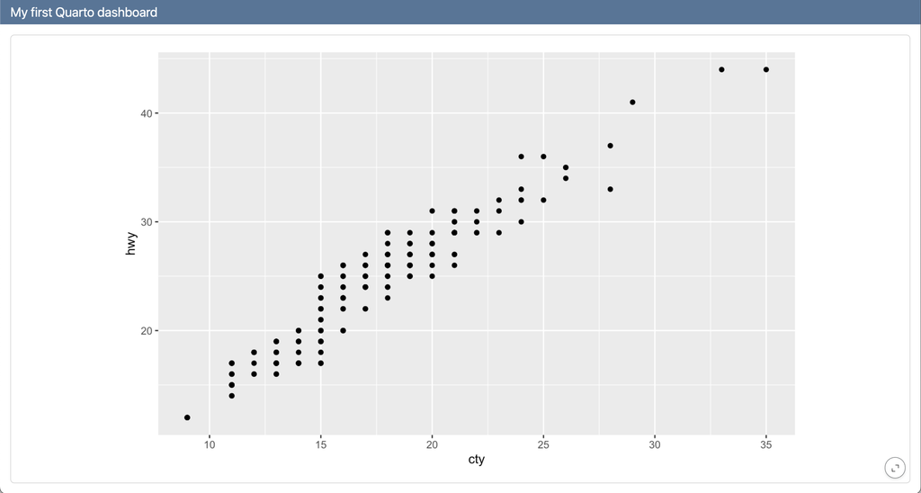

````yaml
---
title: "Meu Primeiro Quarto dashboard"
format: dashboard
---

```{r}
library(ggplot2)
```

```{r}
ggplot(mpg, aes(x = cty, y = hwy)) +
  geom_point()
```
````

## Passo 3: Adicione outro card

```
dashboard-r.qmd
```

````yaml
---
title: "Meu Primeiro Quarto dashboard"
format: dashboard
---

```{r}
library(ggplot2)
```

```{r}
ggplot(mpg, aes(x = cty, y = hwy)) +
  geom_point()
```

```{r}
ggplot(mpg, aes(x = drv)) +
  geom_bar()
```
````

## Passo 3: Adicione outro card

```
dashboard-r.qmd
```

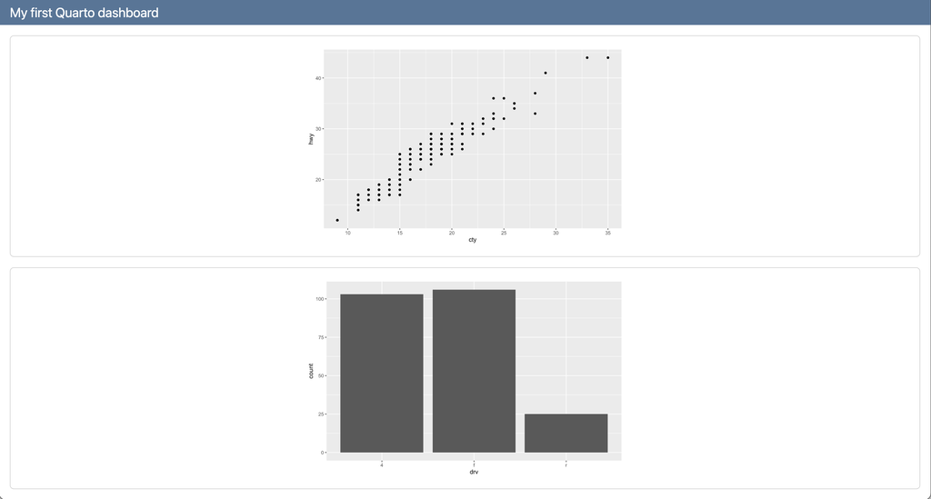

````yaml
---
title: "Meu Primeiro Quarto dashboard"
format: dashboard
---

```{r}
library(ggplot2)
```

```{r}
ggplot(mpg, aes(x = cty, y = hwy)) +
  geom_point()
```

```{r}
ggplot(mpg, aes(x = drv)) +
  geom_bar()
```
````

## Passo 4: Adicione titles aos cards

```
dashboard-r.qmd
```

````yaml
---
title: "Meu Primeiro Quarto dashboard"
format: dashboard
---

```{r}
library(ggplot2)
```

```{r}
#| title: Highway vs. city mileage
ggplot(mpg, aes(x = cty, y = hwy)) +
  geom_point()
```

```{r}
#| title: Drive types
ggplot(mpg, aes(x = drv)) +
  geom_bar()
```
````

## Passo 4: Adicione titles aos cards

```
dashboard-r.qmd
```

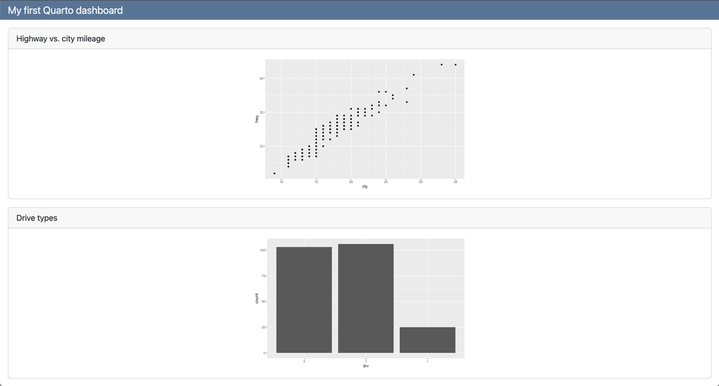

````yaml
---
title: "Meu Primeiro Quarto dashboard"
format: dashboard
---

```{r}
library(ggplot2)
```

```{r}
#| title: Highway vs. city mileage
ggplot(mpg, aes(x = cty, y = hwy)) +
  geom_point()
```

```{r}
#| title: Drive types
ggplot(mpg, aes(x = drv)) +
  geom_bar()
```
````

## Passos 1 - 4

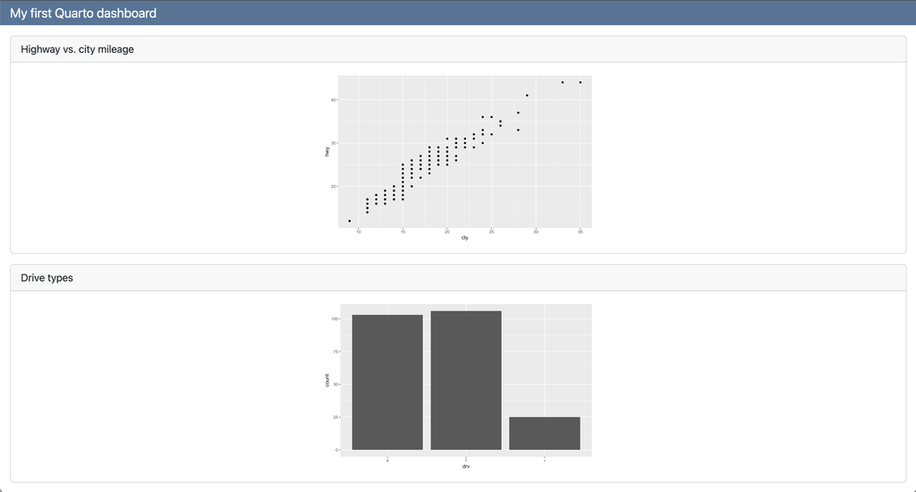

# Páginas e Logo

## Pages

```
dashboard-r.qmd
```

````yaml
---
title: "Pages"
format: dashboard
---

```{r}
library(ggplot2)
```

# Scatter

```{r}
#| title: Highway vs. city mileage
ggplot(mpg, aes(x = cty, y = hwy)) +
  geom_point()
```

# Bar

```{r}
#| title: Drive types
ggplot(mpg, aes(x = drv)) +
  geom_bar()
```
````

## Pages

```
dashboard-r.qmd
```

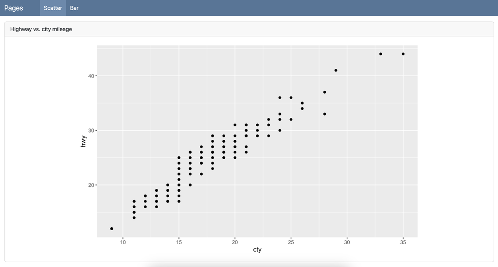

````yaml
---
title: "Pages"
format: dashboard
---

```{r}
library(ggplot2)
```

# Scatter

```{r}
#| title: Highway vs. city mileage
ggplot(mpg, aes(x = cty, y = hwy)) +
  geom_point()
```

# Bar

```{r}
#| title: Drive types
ggplot(mpg, aes(x = drv)) +
  geom_bar()
```
````

## Pages

```
dashboard-r.qmd
```

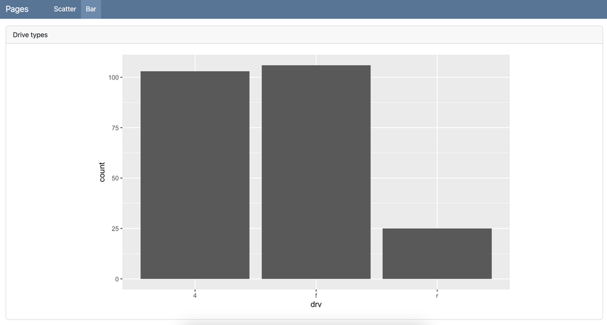

````yaml
---
title: "Pages"
format: dashboard
---

```{r}
library(ggplot2)
```

# Scatter

```{r}
#| title: Highway vs. city mileage
ggplot(mpg, aes(x = cty, y = hwy)) +
  geom_point()
```

# Bar

```{r}
#| title: Drive types
ggplot(mpg, aes(x = drv)) +
  geom_bar()
```
````

## Logo

```
dashboard-r.qmd
```

````yaml
---
title: "Logo"
format:
  dashboard:
    logo: img/fusca.jpeg
---

```{r}
library(ggplot2)
```

# Scatter

```{r}
#| title: Highway vs. city mileage
ggplot(mpg, aes(x = cty, y = hwy)) +
  geom_point()
```

# Bar

```{r}
#| title: Drive types
ggplot(mpg, aes(x = drv)) +
  geom_bar()
```
````

## Logo

```
dashboard-r.qmd
```

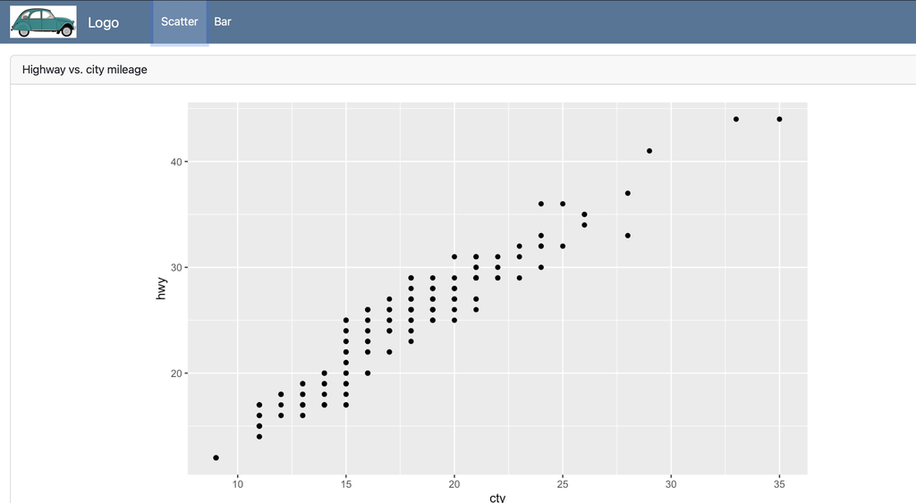

````yaml
---
title: "Logo"
format:
  dashboard:
    logo: img/fusca.jpeg
---

```{r}
library(ggplot2)
```

# Scatter

```{r}
#| title: Highway vs. city mileage
ggplot(mpg, aes(x = cty, y = hwy)) +
  geom_point()
```

# Bar

```{r}
#| title: Drive types
ggplot(mpg, aes(x = drv)) +
  geom_bar()
```
````

# Sidebars, rows, columns, e tabsets

## Sidebars

- Para inserir informações sobre o dashboard, os dados, etc. e/ou para entradas do usuário em dashboards interativos.
- Pode ser inserida globalmente ou em uma página.

## Sidebars - Global

```
dashboard-r.qmd
```

````yaml
---
title: "Sidebars - Global"
format:
  dashboard:
    logo: img/fusca.jpeg
---

```{r}
library(ggplot2)
```

# {.sidebar}

As informações e/ou interatividade que você deseja em todas as páginas
vão aqui.

# Scatter

```{r}
#| title: Highway vs. city mileage
ggplot(mpg, aes(x = cty, y = hwy)) +
  geom_point()
```

# Bar

```{r}
#| title: Drive types
ggplot(mpg, aes(x = drv)) +
  geom_bar()
```
````

## Sidebars - Global

```
dashboard-r.qmd
```

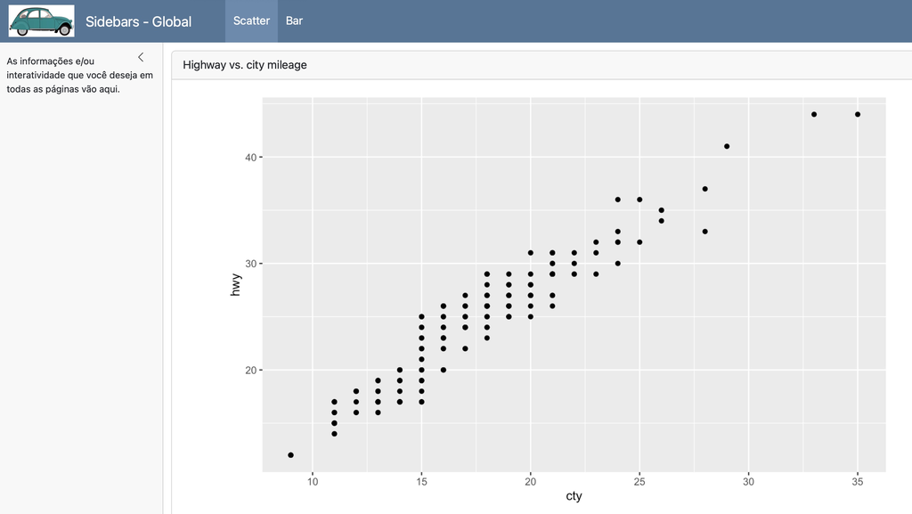

````yaml
---
title: "Sidebars - Global"
format:
  dashboard:
    logo: img/fusca.jpeg
---

```{r}
library(ggplot2)
```

# {.sidebar}

As informações e/ou interatividade que você deseja em todas as páginas
vão aqui.

# Scatter

```{r}
#| title: Highway vs. city mileage
ggplot(mpg, aes(x = cty, y = hwy)) +
  geom_point()
```

# Bar

```{r}
#| title: Drive types
ggplot(mpg, aes(x = drv)) +
  geom_bar()
```
````

## Sidebars - Global

```
dashboard-r.qmd
```

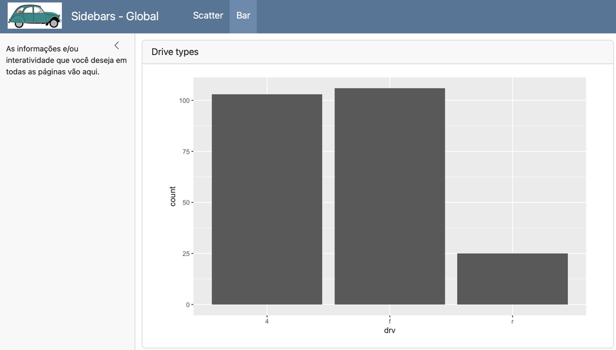

````yaml
---
title: "Sidebars - Global"
format:
  dashboard:
    logo: img/fusca.jpeg
---

```{r}
library(ggplot2)
```

# {.sidebar}

As informações e/ou interatividade que você deseja em todas as páginas
vão aqui.

# Scatter

```{r}
#| title: Highway vs. city mileage
ggplot(mpg, aes(x = cty, y = hwy)) +
  geom_point()
```

# Bar

```{r}
#| title: Drive types
ggplot(mpg, aes(x = drv)) +
  geom_bar()
```
````

## Sidebars - Page

```
dashboard-r.qmd
```

````yaml
---
title: "Sidebars - Per page"
format:
  dashboard:
    logo: img/fusca.jpeg
---

```{r}
library(ggplot2)
```

# Scatter

## {.sidebar}

As informações e/ou interatividade que você deseja em uma única página
vão aqui.

##

```{r}
#| title: Highway vs. city mileage
ggplot(mpg, aes(x = cty, y = hwy)) +
  geom_point()
```

# Bar

```{r}
#| title: Drive types
ggplot(mpg, aes(x = drv)) +
  geom_bar()
```
````

## Sidebars - Page

```
dashboard-r.qmd
```

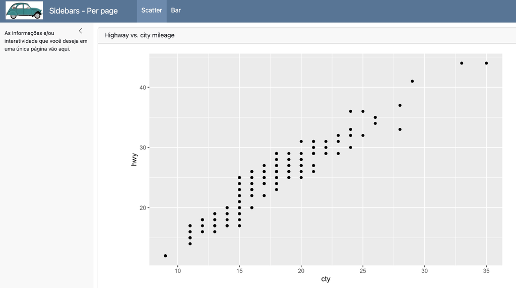

````yaml
---
title: "Sidebars - Per page"
format:
  dashboard:
    logo: img/fusca.jpeg
---

```{r}
library(ggplot2)
```

# Scatter

## {.sidebar}

As informações e/ou interatividade que você deseja em uma única página
vão aqui.

##

```{r}
#| title: Highway vs. city mileage
ggplot(mpg, aes(x = cty, y = hwy)) +
  geom_point()
```

# Bar

```{r}
#| title: Drive types
ggplot(mpg, aes(x = drv)) +
  geom_bar()
```
````

## Sidebars - Page

```
dashboard-r.qmd
```

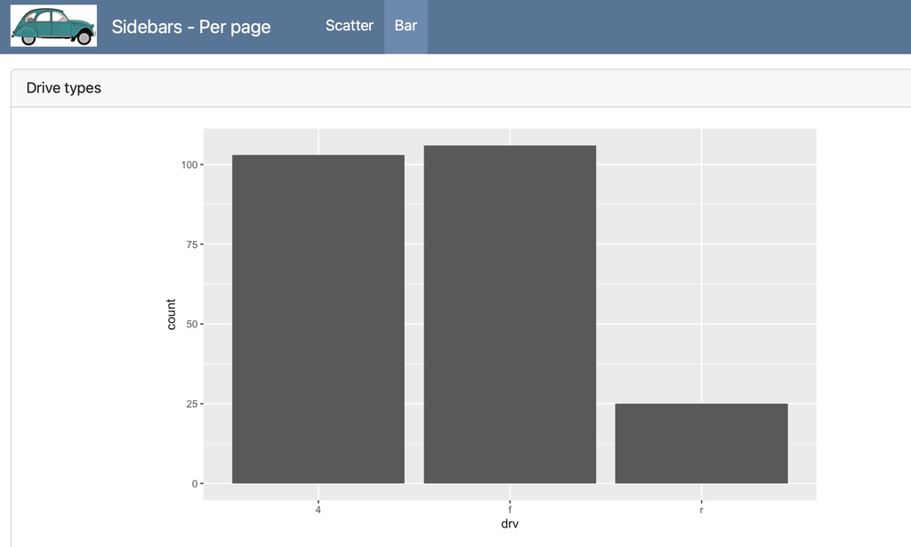

````yaml
---
title: "Sidebars - Per page"
format:
  dashboard:
    logo: img/fusca.jpeg
---

```{r}
library(ggplot2)
```

# Scatter

## {.sidebar}

As informações e/ou interatividade que você deseja em uma única página
vão aqui.

##

```{r}
#| title: Highway vs. city mileage
ggplot(mpg, aes(x = cty, y = hwy)) +
  geom_point()
```

# Bar

```{r}
#| title: Drive types
ggplot(mpg, aes(x = drv)) +
  geom_bar()
```
````

## Rows

Por padrão, os cards são dispostos em linhas:

```
dashboard-r.qmd
```

````yaml
---
title: "Rows"
format:
  dashboard:
    logo: img/fusca.jpeg
---

```{{r}
library(ggplot2)
```

## Scatter

```{r}
#| title: Highway vs. city mileage
ggplot(mpg, aes(x = cty, y = hwy)) +
  geom_point()
```

## Bar

```{r}
#| title: Drive types
ggplot(mpg, aes(x = drv)) +
  geom_bar()
```
````

## Rows

```
dashboard-r.qmd
```

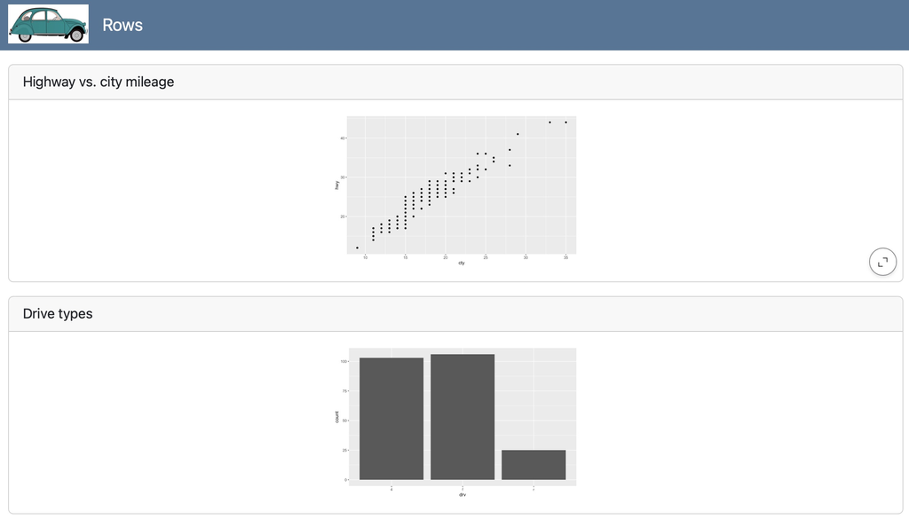

````yaml
---
title: "Rows"
format:
  dashboard:
    logo: img/fusca.jpeg
---

```{{r}
library(ggplot2)
```

## Scatter

```{r}
#| title: Highway vs. city mileage
ggplot(mpg, aes(x = cty, y = hwy)) +
  geom_point()
```

## Bar

```{r}
#| title: Drive types
ggplot(mpg, aes(x = drv)) +
  geom_bar()
```
````

## Rows

O valor padrão da chave `orientation` é `rows`:

```
dashboard-r.qmd
```

````yaml
---
title: "Rows"
format:
  dashboard:
    orientation: rows
    logo: img/fusca.jpeg
---

```{r}
library(ggplot2)
```

## Scatter

```{r}
#| title: Highway vs. city mileage
ggplot(mpg, aes(x = cty, y = hwy)) +
  geom_point()
```

## Bar

```{r}
#| title: Drive types
ggplot(mpg, aes(x = drv)) +
  geom_bar()
```
````

## Columns

Definir `orientation` como `columns` faz com que cada `##` indique uma coluna em vez de uma linha:

```
dashboard-r.qmd
```

````yaml
---
title: "Columns"
format:
  dashboard:
    orientation: columns
    logo: img/fusca.jpeg
---

```{r}
library(ggplot2)
```

## Scatter

```{r}
#| title: Highway vs. city mileage
ggplot(mpg, aes(x = cty, y = hwy)) +
  geom_point()
```

## Bar

```{r}
#| title: Drive types
ggplot(mpg, aes(x = drv)) +
  geom_bar()
```
````

## Columns

```
dashboard-r.qmd
```

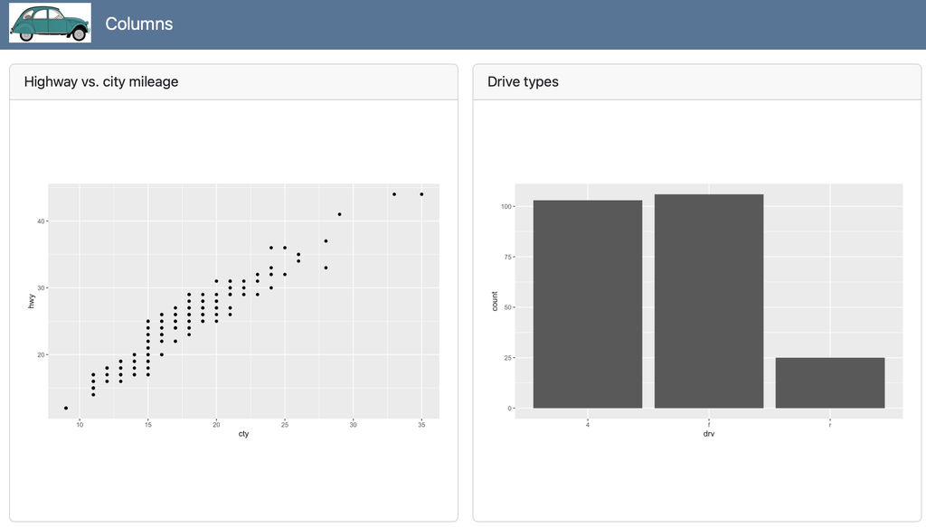

````yaml
---
title: "Columns"
format:
  dashboard:
    orientation: columns
    logo: img/fusca.jpeg
---

```{r}
library(ggplot2)
```

## Scatter

```{r}
#| title: Highway vs. city mileage
ggplot(mpg, aes(x = cty, y = hwy)) +
  geom_point()
```

## Bar

```{r}
#| title: Drive types
ggplot(mpg, aes(x = drv)) +
  geom_bar()
```
````

## Tabsets

```
dashboard-r.qmd
```

````yaml
---
title: "Tabsets"
format:
  dashboard:
    logo: img/fusca.jpeg
---

```{r}
library(ggplot2)
```

## Visão Geral {.tabset}

### Objetivo

Este painel resume uma análise sobre a economia de combustível de
carros.

### Carro

Isto é um carro

![](img/fusca.jpeg){fig-alt="Ilustração de um carro." width="299"}

## Gráficos {.tabset}

### Scatter

```{r}
#| title: Highway vs. city mileage
ggplot(mpg, aes(x = cty, y = hwy)) +
  geom_point()
```

### Bar

```{r}
#| title: Drive types
ggplot(mpg, aes(x = drv)) +
  geom_bar()
```
````

## Tabsets

Cada card dentro de uma linha/coluna ou cada linha/coluna dentro de outra se torna uma aba:

```
dashboard-r.qmd
```

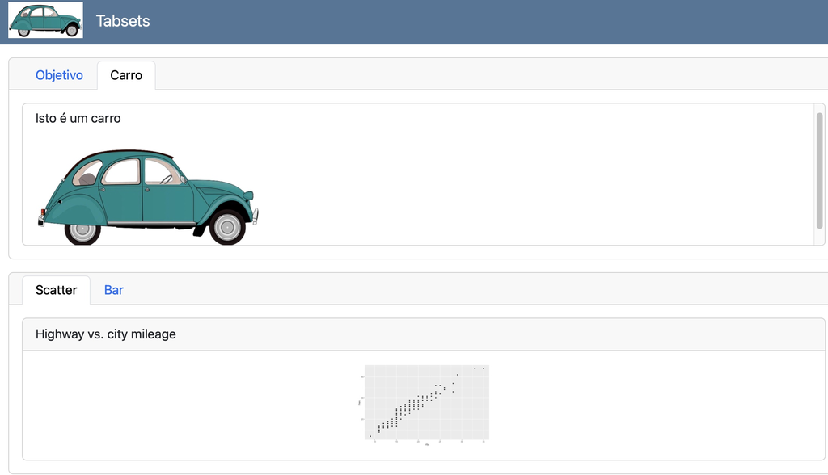

````yaml
---
title: "Tabsets"
format:
  dashboard:
    logo: img/fusca.jpeg
---

```{r}
library(ggplot2)
```

## Visão Geral {.tabset}

### Objetivo

Este painel resume uma análise sobre a economia de combustível de
carros.

### Carro

Isto é um carro

![](img/fusca.jpeg){fig-alt="Ilustração de um carro." width="299"}

## Gráficos {.tabset}

### Scatter

```{r}
#| title: Highway vs. city mileage
ggplot(mpg, aes(x = cty, y = hwy)) +
  geom_point()
```

### Bar

```{r}
#| title: Drive types
ggplot(mpg, aes(x = drv)) +
  geom_bar()
```
````

## Value boxes

- Value boxes são uma ótima maneira de exibir valores simples de forma proeminente em um painel.
- Você pode criar caixas de valor em células executáveis ou markdown simples em `divs`.
- Value boxes usam ícones Bootstrap https://icons.getbootstrap.com e podem ser definidas para qualquer cor (por exemplo, com um código HEX)

  | Color alias | Default theme color(s) |
  | --- | --- |
  | `primary` | Azum |
  | `secondary` | Cinza |
  | `success` | Verde |
  | `info` | Azul brilhante |
  | `warning` | Amarelo/Laranja |
  | `danger` | Vermelho |
  | `light` | Cinza claro |
  | `dark` | Preto |

## Value boxes

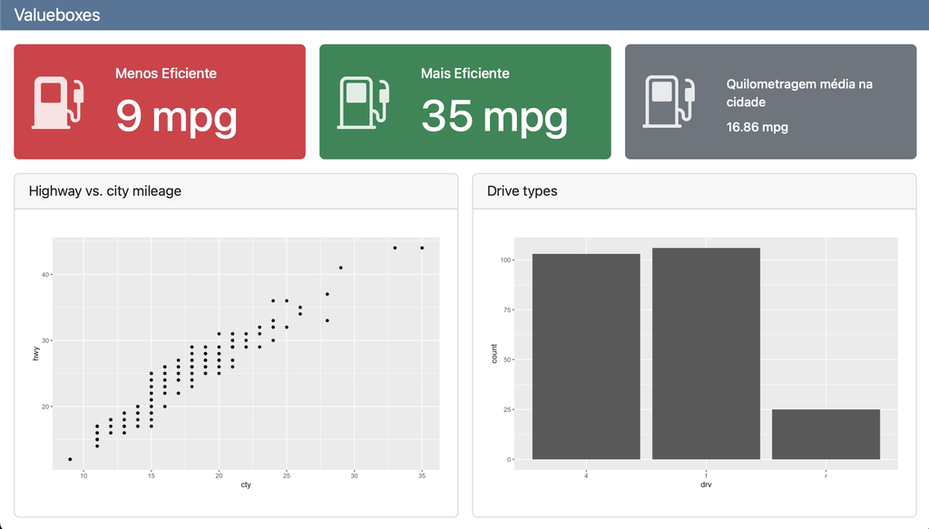

## Dashboard Completo

**Descrição**

- O arquivo `dashboard_completo.qmd` contém um exemplo de um dashboard quarto mais completo.
- Esse dashboard contém gráficos interativos elaborados coms os pacotes **plotly** (gráfico de linha) e **highcharter** (gráficos de barras), além de uma tabela elaborada com o pacote **gt**
- Abra e renderize o arquivo `dashboard_completo.qmd` para ver o resultado.

## Desafio: Publique o Dashboard no GitHub

**Instruções para publicar usando as GitHub Pages**

Para publicar o dashboard no GitHub, você deve:

1. Renderizar o arquivo `dashboard-completo.qmd` para gerar o HTML do dashboard.
2. Criar uma pasta chamada **docs** na raíz do seu projeto
3. Copiar o arquivo `dasboard_completo.html` gerado para a pasta `docs` e renomear esse arquivo para `index.html`.
4. Atualizar o repositório no GitHub como você já aprendeu:
   - git status
   - git add .
   - git status (verifique se todos os arquivos estão na cor verde)
   - git commit -m “Adiciona dashboard completo”
   - git push origin main
5. Acesse o seu repositório no GitHub e vá até a aba **Settings > Pages**.
6. Em **“Source”**, selecione:
   - Branch: `main`
   - Pasta: `/docs`
   - Clique em **“Save”**
7. Se tudo estiver correto, você verá uma mensagem de sucesso e o link para acessar o seu dashboard publicado.

## Referências

- [Quarto Dashboards](https://quarto.org/docs/dashboards/)

## Obrigado!

> > “Os estudantes não sabem o que precisam saber até que precisem saber.”

The Handbook for Economics Lecturers.